# Power_analysis

Rosewood

2025-09-08

# Introduction

This document presents a simulated power analysis for a 3x2x3 fully within-subjects repeated-measures ANOVA, separately considering two dependent variables: **Response Time (RT)** and **Accuracy**.

**Hypotheses:** * **Center Looming Audio:** Enhanced visual orientation sensitivity for center audio compared to silent, indicated by higher accuracy and/or faster RT. * **Side Looming Audio:** Asymmetric effects, with better performance (higher accuracy/faster RT) when audio and visual stimuli are spatially congruent. * **Peripheral Effect:** The facilitatory effect of auditory looming is more pronounced for peripheral visual targets. * **Difficulty Dependence:** Impact of auditory looming varies with difficulty, with the most significant effects at intermediate levels.

# Method

The power analysis is conducted by simulating data for each dependent variable separately. For each sample size tested, data is simulated multiple times, an ANOVA is run, and the proportion of significant results determines the power.

## Setup

First, we load the `tidyverse` for data manipulation and the `afex` package for repeated-measures ANOVA.

```r
# Install packages if not already installed
if (!requireNamespace("tidyverse", quietly = TRUE)) {
  install.packages("tidyverse")
}
if (!requireNamespace("afex", quietly = TRUE)) {
  install.packages("afex")
}

# Load packages
library(tidyverse)
library(afex)
```

```r
# --- Define Design Parameters ---
auditory_levels <- c("Silent", "Center", "Side")
location_levels <- c("Foveal", "Peripheral")
difficulty_levels <- c("Low", "Medium", "High")

# Number of levels for each factor
n_auditory <- length(auditory_levels)
n_location <- length(location_levels)
n_difficulty <- length(difficulty_levels)

# Set common simulation parameters
r <- 0.6       # Correlation among repeated measures
alpha <- 0.05  # Alpha level for significance testing
nsim <- 1000   # Number of simulations
```

## Response Time (RT) Power Analysis

```r
# Hypothesized means for RT (~500ms scale)
mu_vector_rt <- c(
  # Silent (Auditory 1)
  500, 520, 540,    # Foveal, Low/Med/High Difficulty (slower)
  510, 530, 550,    # Peripheral, Low/Med/High Difficulty (slower)

  # Center Auditory (Auditory 2) - Faster RTs
  490, 500, 530,   # Foveal, Low/Med/High Difficulty
  490, 505, 535,   # Peripheral, Low/Med/High Difficulty (more pronounced effect)

  # Side Auditory (Auditory 3) - Asymmetric effects, faster on medium difficulty
  500, 520, 540,   # Foveal, Low/Med/High Difficulty
  510, 480, 530    # Peripheral, Low/Med/High Difficulty (Faster on medium)
)

# Set variance parameters for RT simulation
sd_between_rt <- 50 # Standard deviation for subject-level effects
sd_error_rt <- 30   # Standard deviation for residual error
```

### RT Simulation and Results

```r
sample_sizes <- seq(10, 100, by = 10)
power_results_rt <- purrr::map_dbl(sample_sizes, ~{
  significant_results <- 0

  for (i in 1:nsim) {
    data_sim <- expand.grid(
      subject = factor(1:.),
      auditory = factor(auditory_levels),
      location = factor(location_levels),
      difficulty = factor(difficulty_levels)
    )

    subject_effects <- rnorm(., mean = 0, sd = sd_between_rt)
    data_sim$y <- mu_vector_rt[
      (as.numeric(data_sim$auditory) - 1) * (n_location * n_difficulty) +
      (as.numeric(data_sim$location) - 1) * n_difficulty +
      as.numeric(data_sim$difficulty)
    ] + subject_effects[data_sim$subject] + rnorm(nrow(data_sim), mean = 0, sd = sd_error_rt)

    model_anova <- afex::aov_ez(
      id = "subject",
      dv = "y",
      between = NULL,
      within = c("auditory", "location", "difficulty"),
      data = data_sim,
      fun_aggregate = mean
    )

    p_value <- anova(model_anova)$`Pr(>F)`[6] # Assuming 6th row is 3-way interaction
    if (!is.na(p_value) && p_value < alpha) {
      significant_results <- significant_results + 1
    }
  }

  significant_results / nsim
})

power_curve_data_rt <- tibble(
  n_subjects = sample_sizes,
  power = power_results_rt
)
```

### Power Curve Results for Response Time (RT)

| n_subjects | power |
| --- | --- |
| 10 | 0.172 |
| 20 | 0.386 |
| 30 | 0.532 |
| 40 | 0.660 |
| 50 | 0.792 |
| 60 | 0.844 |
| 70 | 0.906 |
| 80 | 0.959 |
| 90 | 0.969 |
| 100 | 0.978 |

**Required sample size (N) for 80% power (RT):** 60

#### RT Power Curve Plot

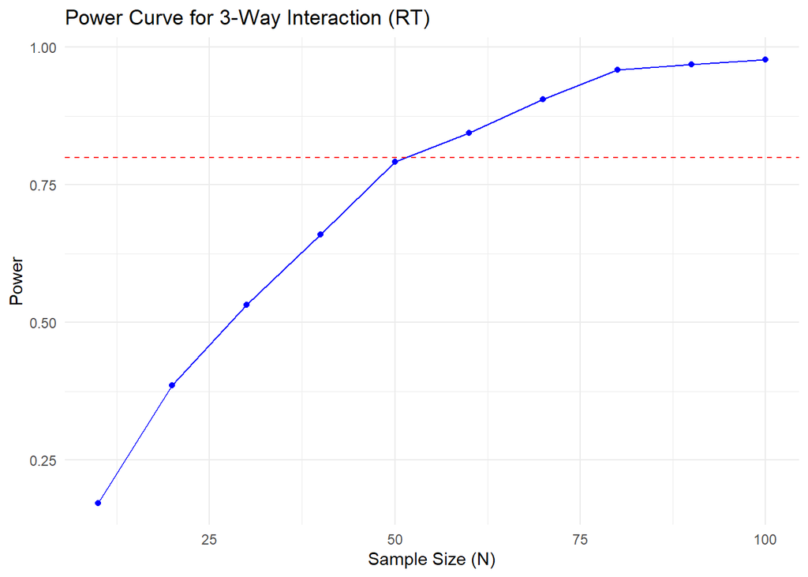

Power Curve for 3-Way Interaction (RT)

## Accuracy (Percentage) Power Analysis

This section focuses on Accuracy as the dependent variable. **Note that higher accuracy is better, so higher mean values represent enhancement.**

### Accuracy Parameters

```r
# Hypothesized means for Accuracy (~percentage scale)
mu_vector_acc <- c(
  # Silent (Auditory 1)
  85, 80, 75,    # Foveal, Low/Med/High Difficulty
  80, 75, 70,    # Peripheral, Low/Med/High Difficulty

  # Center Auditory (Auditory 2) - Higher accuracy
  88, 83, 78,   # Foveal, Low/Med/High Difficulty
  83, 85, 78,   # Peripheral, Low/Med/High Difficulty (more pronounced effect)

  # Side Auditory (Auditory 3) - Asymmetric effects, higher on medium difficulty
  87, 82, 77,   # Foveal, Low/Med/High Difficulty
  82, 90, 77    # Peripheral, Low/Med/High Difficulty (Higher on medium)
)

# Set variance parameters for Accuracy simulation
sd_between_acc <- 5 # Standard deviation for subject-level effects
sd_error_acc <- 5   # Standard deviation for residual error
```

### Accuracy Simulation and Results

```r
power_results_acc <- purrr::map_dbl(sample_sizes, ~{
  significant_results <- 0

  for (i in 1:nsim) {
    data_sim <- expand.grid(
      subject = factor(1:.),
      auditory = factor(auditory_levels),
      location = factor(location_levels),
      difficulty = factor(difficulty_levels)
    )

    subject_effects <- rnorm(., mean = 0, sd = sd_between_acc)
    data_sim$y <- mu_vector_acc[
      (as.numeric(data_sim$auditory) - 1) * (n_location * n_difficulty) +
      (as.numeric(data_sim$location) - 1) * n_difficulty +
      as.numeric(data_sim$difficulty)
    ] + subject_effects[data_sim$subject] + rnorm(nrow(data_sim), mean = 0, sd = sd_error_acc)

    model_anova <- afex::aov_ez(
      id = "subject",
      dv = "y",
      between = NULL,
      within = c("auditory", "location", "difficulty"),
      data = data_sim,
      fun_aggregate = mean
    )

    p_value <- anova(model_anova)$`Pr(>F)`[6] # Assuming 6th row is 3-way interaction
    if (!is.na(p_value) && p_value < alpha) {
      significant_results <- significant_results + 1
    }
  }

  significant_results / nsim
})

power_curve_data_acc <- tibble(
  n_subjects = sample_sizes,
  power = power_results_acc
)
```

### Power Curve Results for Accuracy (Percentage)

| n_subjects | power |
| --- | --- |
| 10 | 0.835 |
| 20 | 0.992 |
| 30 | 1.000 |
| 40 | 1.000 |
| 50 | 1.000 |
| 60 | 1.000 |
| 70 | 1.000 |
| 80 | 1.000 |
| 90 | 1.000 |
| 100 | 1.000 |

**Required sample size (N) for 80% power (Accuracy):** 10

#### Accuracy Power Curve Plot

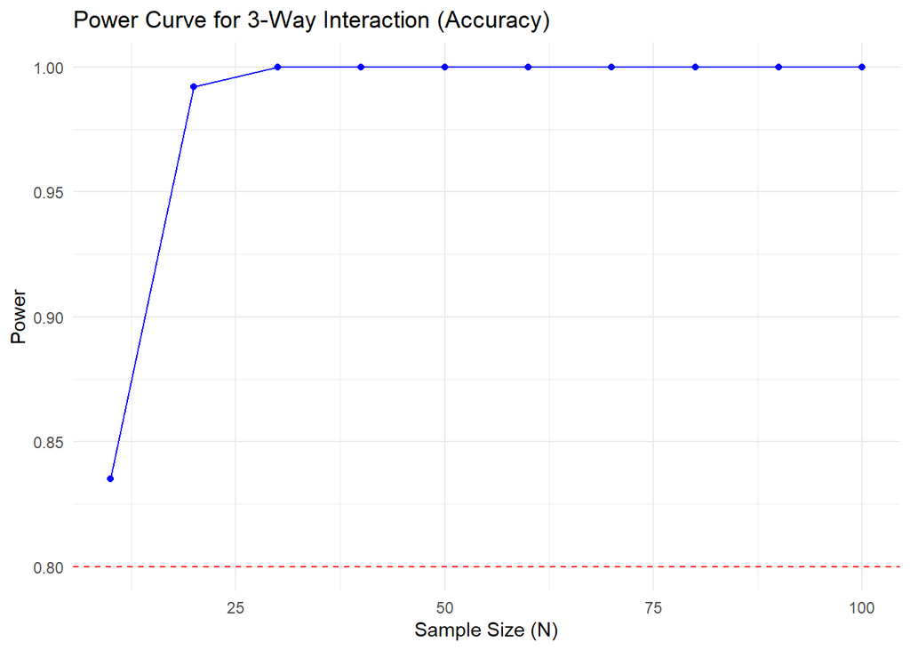

Power Curve for 3-Way Interaction (Accuracy)